# TSP in R Part 1

Philip Bulsink

2017-03-27

Last time we created a distance matrix and a time matrix for use in TSP problems. We’re using a set of locations in the Ottawa, Ontario, Canada area, but any list of locations with addresses would work.

We’ll start this time by loading the data we saved last time:

```r
distance_matrix<-readRDS("./distance_matrix.RDS")
time_matrix<-readRDS("./time_matrix.RDS")
```

Much of this post is informed by the [vignette in the TSP package](https://cran.r-project.org/web/packages/TSP/vignettes/TSP.pdf). There’s lots of great documentation in a more ‘tutorial’ type format than the official documentation in R vignettes.

We’ll start by making these matrices ‘TSP’ compatable objects.

```r
ottawa_dm<-ATSP(distance_matrix)
ottawa_tm<-ATSP(time_matrix)
```

Note that we use the ATSP function. The matrices we’re feeding in aren’t symmetrical. It may take longer or be farther to go from point A to point B than it is to go from B to A. This could be due to traffic, one way streets, the number of left hand turns, etc.

We can look at a few properties of this ATSP class:

```r
print(ottawa_dm)
```

```
## object of class 'ATSP'  (asymmetric TSP)
## 46 cities (distance 'unknown')
```

```r
head(labels(ottawa_dm))
```

```
## [1] "24 Sussex Dr, Ottawa, ON K1M 1M4, Canada"
## [2] "2100 Cabot St, Ottawa, ON K1H 6K1, Canada"
## [3] "2777 Cassels St, Ottawa, ON K2B 6N6, Canada"
## [4] "1 Canal Ln, Ottawa, ON K1P 5P6, Canada"
## [5] "55 Byward Market Square, Ottawa, ON K1N 9C3, Canada"
## [6] "2 Queen Elizabeth Dr, Ottawa, ON K2P 2H9, Canada"
```

We can also visualize a shaded matrix of the distances between objects:

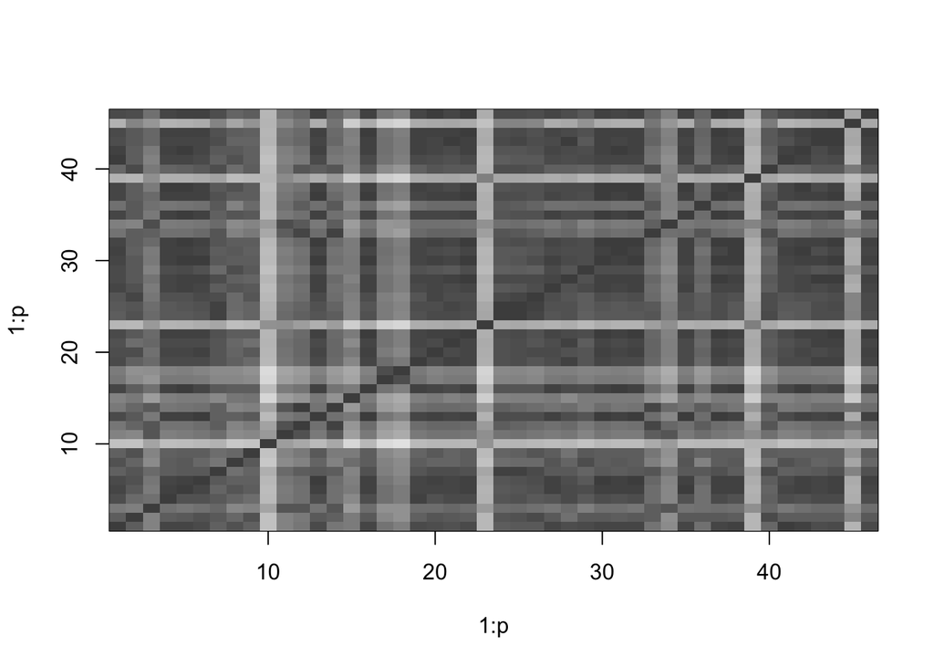

```r
image(ottawa_dm)
```

Let’s solve the TSP by each of the internal methods and see what minimum distance for each we get:

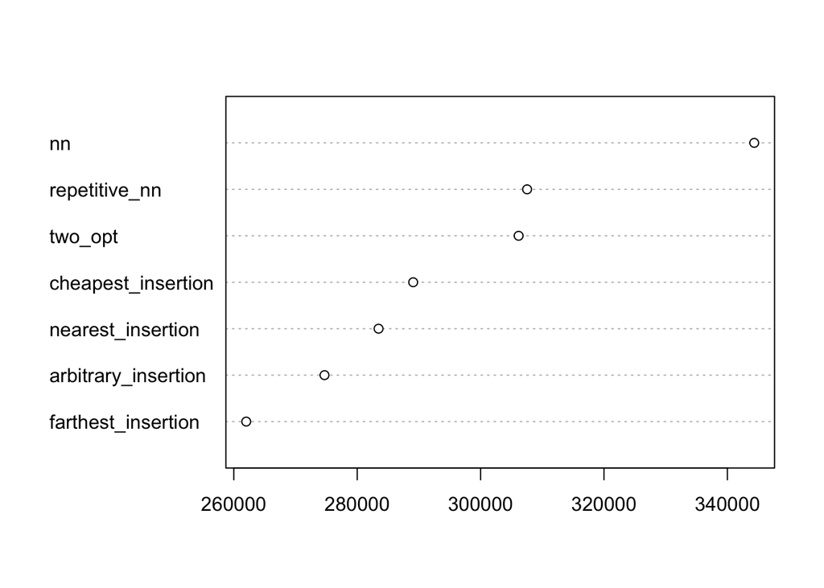

```r
methods <- c("nearest_insertion", "farthest_insertion", "cheapest_insertion",
"arbitrary_insertion", "nn", "repetitive_nn", "two_opt")
dm_tours <- sapply(methods, FUN = function(m) solve_TSP(ottawa_dm, method = m), simplify = FALSE)

dotchart(sort(c(sapply(dm_tours, tour_length))))
```

Concorde, Chained Lin-Kernighan (`linkern`) and other solvers can only do symmetric TSP. A function will convert our ATSP problem to a TSP for use with these advanced solvers. This function doubles each city, providing an ‘in’ and an ‘out’ city, with distance 0 between them (set as `cheap = 0`).

```r
ottawa_dm_tsp<-reformulate_ATSP_as_TSP(ottawa_dm, cheap = 0)
ottawa_tm_tsp<-reformulate_ATSP_as_TSP(ottawa_tm, cheap = 0)

print(ottawa_dm_tsp)
```

```
## object of class 'TSP'
## 92 cities (distance 'unknown')
```

We have to set the Concorde TSP path. It seems to work only with an abspath, no `~` involved.

```r
concorde_path("/Users/pbulsink/concorde/TSP")
```

```
## found: concorde concorde.c concorde.o
```

We’ll try solve the TSP using concorde:

```r
dm_tours$concorde <- solve_TSP(ottawa_dm_tsp, method="concorde", control = list(verbose=FALSE))
dm_tours$concorde
```

```
## object of class 'TOUR'
## result of method 'concorde' for 92 cities
## tour length: 258751
```

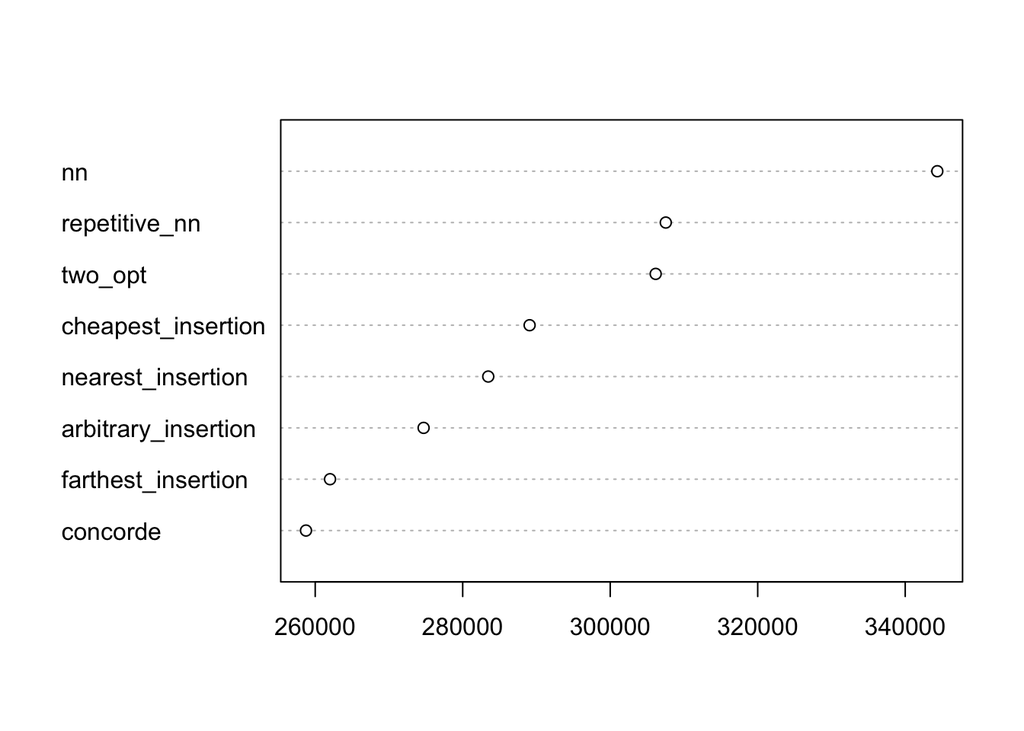

```r
dotchart(sort(c(sapply(dm_tours, tour_length))))
```

Similarly, we’ll reset the path to use the Chained Lin-Kernighan (`linkern`) method:

```r
concorde_path("/Users/pbulsink/concorde/LINKERN")
```

```
## found: linkern linkern_fixed.c linkern_fixed.o linkern_path.c linkern_path.o linkern.a linkern.c linkern.o
```

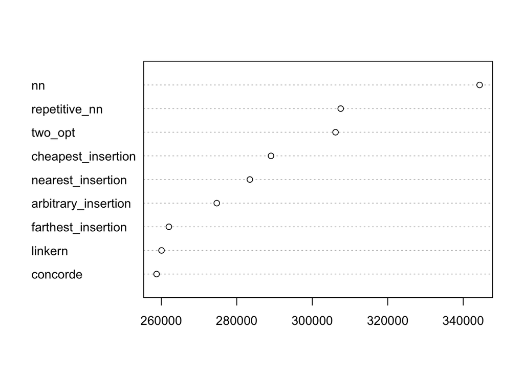

```r
dm_tours$linkern <- solve_TSP(ottawa_dm_tsp, method="linkern", control = list(verbose=FALSE))
dotchart(sort(c(sapply(dm_tours, tour_length))))
```

By looking at the bottom of the dot plot, we can see that the Lin-Kernighan and Concorde solvers provide the most optimal routes, and assorted substitution algorithms provide less qualified answers.

Next post we’ll discuss mapping the routes visually.

*Remember that Concorde is licenced for academic use only, all other uses must be requested on the Concorde website.*